# Expected Profit Analysis: A Statistical Approach to Airline Overbooking

Serafim Petrov

December 14, 2024

## Abstract

This research explores the statistical analysis of overbooking in the airline industry. The objective is to predict passenger turnout and evaluate the potential profits from ticket sales. By understanding these dynamics, airlines can optimize their ticket sales strategy, balancing profitability against customer satisfaction.

## Problem Statement

Airlines face the challenge of overbooking, wherein they sell more tickets than available seats to account for no-shows. This study presents an analytical solution and its implementation in R, modeling the number of passengers who show up as a binomial random variable to calculate expected profit.

## Results

Assuming a show-up probability of 0.98, a seat capacity of 100, a ticket price of $200, and a bump compensation of $500, the analysis reveals that an optimal reservation count of 101 maximizes expected profit at $19,705. This finding emphasizes the balance between ticket sales and capacity management to enhance revenue in the airline sector.

## Details:

### Analytical Solution

#### 1. Definitions and Assumptions

Let:

- $n$ be the total number of reservations made.
- $p = 0.98$ be the probability a reserved passenger shows up.
- $100$ to be the seat capacity of an airplane.

The number of passengers that show up, $X$, is iid and follows a Binomial distribution:
$$X \sim \text{Binomial}(n, p)$$

#### 2. Profit Calculation

Let:

- $r = 200$ be the profit per passenger,
- $c = 500$ be the compensation cost for each bumped passenger.

The profit $Y$ is defined as:
$$Y =
\begin{cases}
rX, & \text{if } X \leq 100, \\
100r - c(X-100), & \text{if } X > 100.
\end{cases}$$

#### 3. Expected Profit Derivation

The expected profit, $E[Y]$, is given by:
$$E[Y] = \sum_{x=0}^{n} Y(x)\, P(X=x)$$
Where:

- $P(X = x)$ is the probability of $x$ passengers showing up, calculated using the binomial probability mass function:
  $$P(X = x) = \binom{n}{x} p^x (1 - p)^{n - x}$$

### R Implementation

The following function implements the mathematical model in R, assisting airlines in estimating potential profits from ticket sales by calculating the likelihood of varying passenger turnout.

#### 1. Function

It considers both the ticket price and compensation costs for any overbooked passengers, providing a clear picture of expected earnings.

```r
expected_profit <- function(n) {
  expected_profit_value <- 0

  for (x in 0:n) {
    prob_x <- choose(n, x) * (show_up_probability^x) * ((1 - show_up_probability)^(n - x))

    if (x <= seats_capacity) {
      profit <- ticket_price * x
    } else {
      profit <- (ticket_price * seats_capacity) - (bump_compensation * (x - seats_capacity))
    }

    expected_profit_value <- expected_profit_value + (prob_x * profit)
  }

  return(expected_profit_value)
}
```

#### 2. Parametrs and optimization

The parameters are defined to iterate over a range of possible scenarious with recoding it to a dataframe:

```r
show_up_probability <- 0.98
seats_capacity <- 100
ticket_price <- 200
bump_compensation <- 500

# Range of reservations to test
n_reservations <- 90:110
results <- data.frame(reservations = n_reservations, expected_profit = NA)
```

Calculate expected profits for each number of reservations and Identify the optimal number of reservations:

```r
for (n in n_reservations) {
  results[results$reservations == n, "expected_profit"] <- expected_profit(n)
}

optimal_n <- results$reservations[which.max(results$expected_profit)]
max_profit <- max(results$expected_profit)
```

#### 3. Output

The maximum expected profit is observed to be $19,705 when 101 reservations are made.

| reservations | expected_profit |
| --- | --- |
| 90 | 17640.0 |
| 91 | 17836.0 |
| 92 | 18032.0 |
| 93 | 18228.0 |
| 94 | 18424.0 |
| 95 | 18620.0 |
| 96 | 18816.0 |
| 97 | 19012.0 |
| 98 | 19208.0 |
| 99 | 19404.0 |
| 100 | 19600.0 |
| 101 | 19705.0 |
| 102 | 19628.1 |
| 103 | 19367.4 |
| 104 | 18981.7 |
| 105 | 18531.7 |
| 106 | 18054.9 |
| 107 | 17568.7 |
| 108 | 17079.7 |
| 109 | 16589.9 |
| 110 | 16100.0 |

#### 4. Visualization

The analysis indicates that the inflection point corresponds to the maximum of the expected profit function:

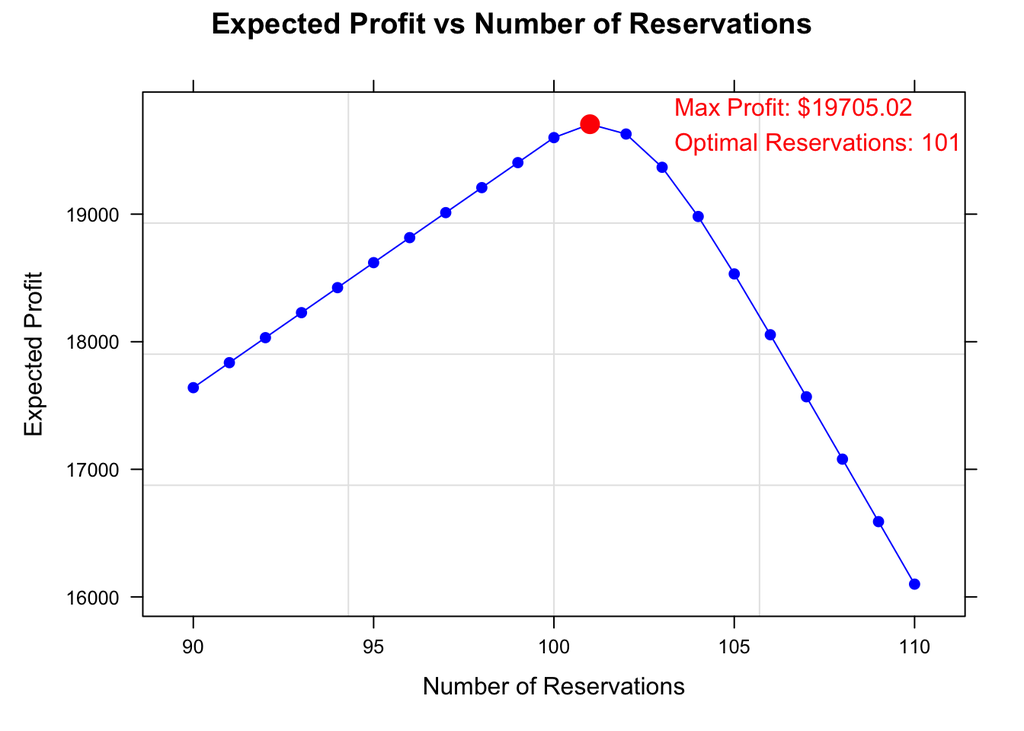

## Conclusion

This research demonstrates how airlines can utilize statistical models to optimize ticket sales and manage overbooking effectively. By predicting passenger turnout and calculating expected profits, airlines are equipped to make informed decisions that enhance revenue while minimizing customer dissatisfaction. The findings indicate that an optimal reservation count of 101 results in the highest expected profit of $19,705, underscoring the significance of data-driven strategies within the airline industry.